# R Notebook

```r
library(ggplot2)
library(expm)
rm(list = ls())
```

# R1 : Processus de Poisson

On commence par créer des fonctions qui permettent de simuler des HPP. Pour un HPP, il nous suffit d’avoir les temps de saut pour connaitre la trajectoire. En effet, le temps de saut Tn amènera dans l’état Yn = n.

```r
# input :
# t = temps de la simulation
# l = paramètre de la loi exponentielle

# output : les temps de sauts (T1,...Tn)

HPP_sim_1 <- function(t,l){

  # le premier temps de saut se fait en t=0
  T0 = 0

  # vecteur des k premiers temps de saut
  Tk_1 = c(T0)

  # condition d'arret
  stop = F

  while(stop == F){

    # le temps de séjour dans l'état courant suit une loi Exp(lambda)
    Sk = rexp(1,l)

    # le prochain saut Tk sera donc en Tk-1 + Sk
    Tk = Sk+Tk_1[length(Tk_1)]

    if (t>Tk){
      # le dernier saut Tk à lieux avant t donc on continue
      Tk_1 = c(Tk_1,Tk)

    } else{
      # on s'arrete car t <= Tk
      # ce generateur peut poser problème si on a un processus explosif
      # car si |t - Tk|<epsilon alors avec la precision machine
      # t = Tk alors que t!=Tk
      stop = T


    }
  }

  return(Tk_1)
}
```

La première fonction de simulation n’utilise pas le calcul matricielle qui est rapide sur R. Cela vient du fait que l’on ne peut pas savoir quand on va dépasser la première fois t dans notre processus de sauts.

Une manière d’optimiser cette méthode est de simuler des un nombre de temps de saut de longueur fixe et de manière à ce que le dernier temps de saut Tn ai de grandes chances d’être supérieur à t. Puis on viendra rogner le vecteur des (Tk) k dans {0,…,n} de manière a trouver n0 tel que Tn0<t et Tn0+1>t. Ainsi on retournera (Tk) k dans {0,…,n0}.

On peut se trouver dans un cas qui serait plutôt peu probable et où l’on aurait Tn<t. Dans ce cas on utilisera le premier simulation en utilisant le caractère Markov de régénération pour compléter le processus pour avoir ce que l’on veut.

```r
# input :
# t = temps de la simulation
# l = paramètre de la loi exponentielle

# output : les temps de sauts (T1,...Tn)

HPP_sim_2 <- function(t,l){

  # on cherche une valeur de n qui ne demande pas de completer le processus
  # Ici on a pris 10*Espérance de la loi de Poisson de paramètre l*t
  # car Xt suit une loi de Poisson de paramètre lt et l'espérance de cette loi est l*t

  n = 10*as.integer(l*t)
  T0 = 0
  Tk = c(T0)
  # on simulte n v.a.i.i.d d de la loi Exp(l), ca sera les temps de séjour c'est à dire les (S1,...,Sn)
  simu = rexp(n,l)

  # par définition des Tk
  Tk = c(Tk,cumsum(simu))

  # vecteur de booléen qui permet de trouver le dernier indice tel que Tk<t
  b = (Tk < t)
  ind = sum(b)




  if (Tk[length(Tk)]<t){
    # Cas que l'on cherche à éviter mais de probabilité non nulle
    # si le dernier indice est inferieur à t alors on doit completer

    print("/!\ Utilisation de HPP_sim_1 pour compléter la trajectoire ")
    T_k_next = HPP_sim_1(t-Tk[ind],l) + Tk[ind]
    return(c(Tk,T_k_next))
  }else{
    return(Tk[1:ind])

  }

}
```

```r
# test
HPP_sim_2(10,2)
```

```
 [1] 0.00000000 0.01793799 0.19561216 0.31001178 1.41515308
 [6] 1.54184888 1.65676233 1.75320368 2.43135191 4.55775967
[11] 5.69327211 5.70080306 5.79362335 6.01001143 6.07706325
[16] 6.12954840 6.17859785 7.11893845 7.49064953 7.92145056
[21] 8.26732525 8.33772846 8.63988056 9.41028909 9.55974318
[26] 9.72970773
```

```r
# input :
# t = temps de la simulation
# l = paramètre de la loi exponentielle

# output : les temps de sauts (T1,...Tn)

HPP_sim_3 <- function(t,l){

  n = rpois(1,l*t) # simulation de la valeur de Xt.
  T0 = 0
  Tk = c(T0)
  if (n == 0){
    return(Tk)

  } else {
    U = runif(n,0,t)

    # on trie nos valeurs.
    Tk = c(Tk,sort(U))

    return(c(Tk))
  }
}
```

```r
# input :
# t = temps de la simulation
# l = paramètre de la loi exponentielle
# n = nombre de trajectoire que l'on veut tracer sur le graphique

# output : un graphique

graphe_HPP <- function(t,l,n,version){
  p = ggplot()
  tps_exe = NULL
  for(i in c(1:n)){

    # cette selection permet de savoir avec quel simulateur on affiche et de même de retourner le temps moyen de calcul de la méthode pour les n             #trajectoires

    # Rq : une méthode sera spécialement écrite pour étudier le temps de calcul dans la suite

    if(version ==1){
        # premiere version qui affiche une trajectoire en utilisant le premier simulateur
        # le simulateur qui utilise la boucle while
      tps = Sys.time()
      Tk = HPP_sim_1(t,l)
      tps_exe = c(Sys.time()-tps,tps_exe)

    }

    else if(version ==2){
        # deuxieme version qui affiche une trajectoire en utilisant le deuxieme simulateur
      tps = Sys.time()
      Tk = HPP_sim_2(t,l)
      tps_exe = c(Sys.time()-tps,tps_exe)

    }
    else if(version==3){
        # troisieme version qui affiche une trajectoire avec le dernier simulateur
      tps = Sys.time()
      Tk = HPP_sim_3(t,l)
      tps_exe = c(Sys.time()-tps,tps_exe)

    }else{
      print("on ne peut pas afficher avec cette version il n'y a que 1, 2 et 3")
      return(-1)
    }

    states = c(0:(length(Tk)-1))
    df = data.frame(states = states,
                    times = Tk)

    p = p +
      geom_step(data = df , aes(x = times , y = states), color=i)+
      geom_point(data=df, mapping=aes(x=times, y=states), color=i) + ggtitle(paste("Simulation du processus de Poisson avec la version",version,"et avec t = ",t,"et lambda = ",l))
  }
  df = data.frame(x=c(0:t),y=c(0:t)*l)

  print(paste("temps d'execution moyen pour",n,"tajectoire(s) du simulateur",version,"est : ",mean(tps_exe),"secondes"))
  plot(p)
}
```

```
[1] "temps d'execution moyen pour 3 tajectoire(s) du simulateur 2 est :  0 secondes"
```

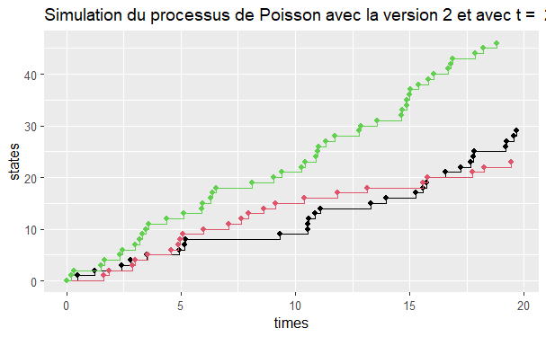

```r
# affichage avec la version 2
t = 20
l = 2
n = 3
version = 2
graphe_HPP(t,l,n,version)
```

```
[1] "temps d'execution moyen pour 3 tajectoire(s) du simulateur 3 est :  0 secondes"
```

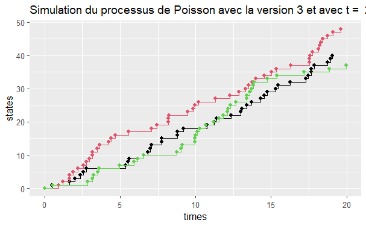

```r
# affichage avec la version 3
t = 20
l = 2
n = 3
version = 3
graphe_HPP(t,l,n,version)
```

```r
# permet d'etudier le temps de calcul des trois simulateurs précédents

# input :
# n = nombre de trajectoire que l'on veut étudier

# output : temps de d'execution moyen des simulateurs en fonction de méthode

time_process = function(n,t,l){
  tps1_vec=NULL
  tps2_vec=NULL
  tps3_vec=NULL
  for(i in c(1:n)){
    tps1 = Sys.time()
    HPP_sim_1(t,l)
    tps1_vec = c(tps1_vec,Sys.time()-tps1)

    tps2 = Sys.time()
    HPP_sim_2(t,l)
    tps2_vec = c(tps2_vec,Sys.time()-tps2)

    tps3 = Sys.time()
    HPP_sim_3(t,l)
    tps3_vec = c(tps3_vec,Sys.time()-tps3)
  }
  print(paste("Le temps d'execution moyen pour HPP_sim_1 est",mean(tps1_vec),"secondes"))
  print(paste("Le temps d'execution moyen pour HPP_sim_2 est",mean(tps2_vec),"secondes"))
  print(paste("Le temps d'execution moyen pour HPP_sim_3 est",mean(tps3_vec),"secondes"))
}
```

```r
# Etude des temps de calcul
n = 1000
t = 50
l = 20
time_process(n,t,l)
```

```
[1] "Le temps d'execution moyen pour HPP_sim_1 est 0.00534230756759644 secondes"
[1] "Le temps d'execution moyen pour HPP_sim_2 est 0.000492816925048828 secondes"
[1] "Le temps d'execution moyen pour HPP_sim_3 est 0.000201936006546021 secondes"
```

```
[1] "temps d'execution moyen pour 10 tajectoire(s) du simulateur 2 est :  0 secondes"
[1] "temps d'execution moyen pour 10 tajectoire(s) du simulateur 3 est :  9.96828079223633e-05 secondes"
[1] "temps d'execution moyen pour 10 tajectoire(s) du simulateur 2 est :  0 secondes"
[1] "temps d'execution moyen pour 10 tajectoire(s) du simulateur 3 est :  0 secondes"
[1] "temps d'execution moyen pour 10 tajectoire(s) du simulateur 2 est :  0 secondes"
[1] "temps d'execution moyen pour 10 tajectoire(s) du simulateur 3 est :  0.000100183486938477 secondes"
[1] "temps d'execution moyen pour 10 tajectoire(s) du simulateur 2 est :  0.000299882888793945 secondes"
[1] "temps d'execution moyen pour 10 tajectoire(s) du simulateur 3 est :  0 secondes"
```

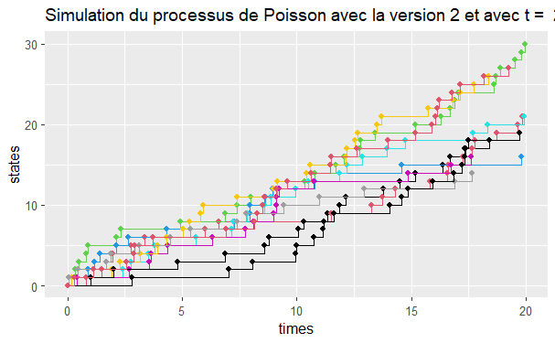

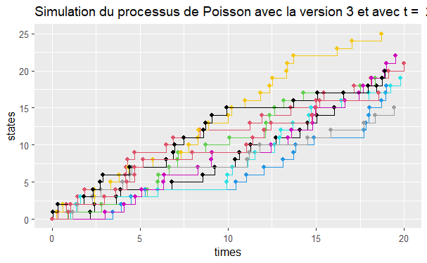

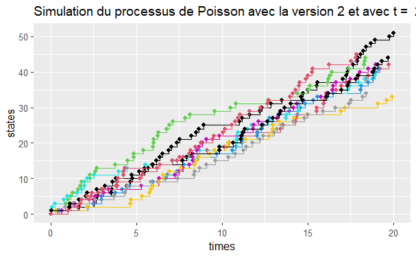

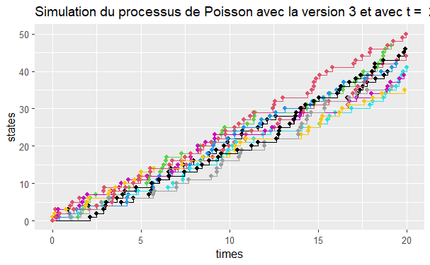

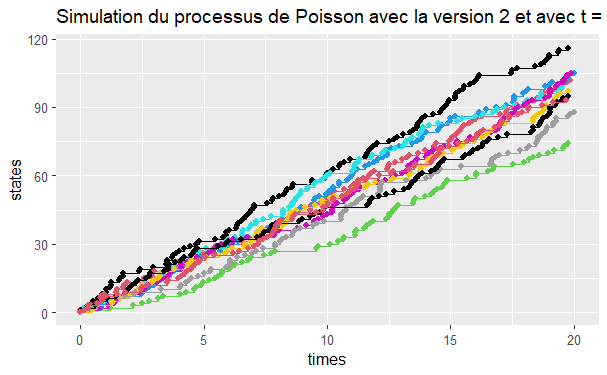

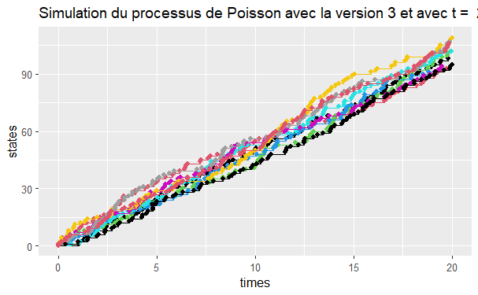

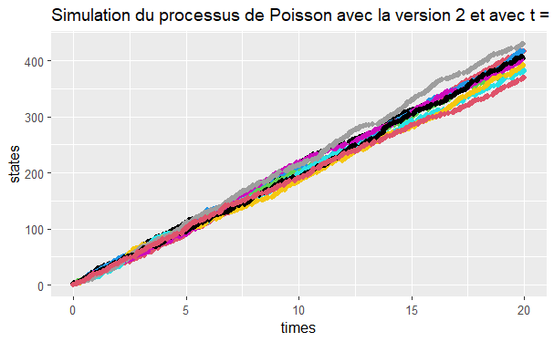

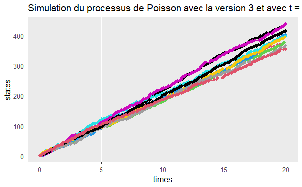

```r
t=20
par(mfrow = c(3,3))
l_vect = c(1,2,5,20)
for (l in l_vect){
  graphe_HPP(t,l,10,2)
  graphe_HPP(t,l,10,3)
}
```

On verifie que l’on simule bien une varible de la loi de Poisson Pour cela on regarde si en sur n échantillon si en ne gardant que la valeur de l’état occupé en t. Si cet échantillon suit bien un loi de Poisson(l*t)

On peut pour cela comparer les fonctions de répartition théoriques avec empiriques et l’histogramme de fréquence avec la densité.

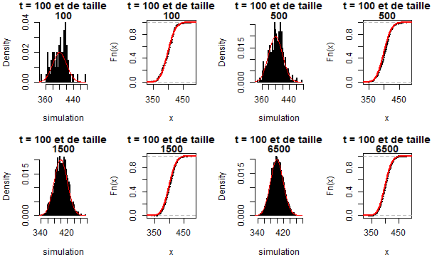

```r
# test de la fonction avec HPP_sim_1

par(mfrow = c(2,4))
l = 4
t = 100

# ici on vient petit à petit compléter l'échantillon nommé simulation
# dans un premier temps celui ci comporte 100 valeurs, puis on vient
# ajouter 500 valeurs donc on aura 600 valeur
# En effet la phylosophie n'est pas de reprendre la simulation à zero
# entre deux comparaisons mais de voir l'évolution avec le nombre de
# valeurs

simulation = NULL
for(n in c(100,400,1000,5000)){
  for(i in c(1:n)){
  simulation = c(simulation,(length(HPP_sim_1(t,l))))
}
title = c("t = 100 et de taille",toString(length(simulation)))
hist(simulation,probability =T,nclass=50,main = title)
lines(c(1:max(simulation)),dpois(c(1:max(simulation)),l*t),col="red")

title =
plot(ecdf(simulation),main=title)
lines(c(300:500),ppois(c(300:500),t*l),col="red",lwd=2)
}
```

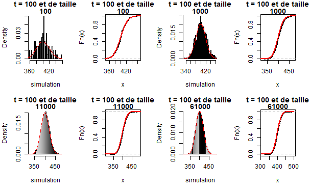

```r
# test de la fonction avec HPP_sim_2

par(mfrow = c(2,4))
l = 4
t = 100
n = 10000
simulation = NULL

for(n in c(100,900,10000,50000)){

  for(i in c(1:n)){
  simulation = c(simulation,(length(HPP_sim_2(t,l))))
}
title = c("t = 100 et de taille",toString(length(simulation)))
hist(simulation,probability =T,nclass=50,main = title)
lines(c(1:max(simulation)),dpois(c(1:max(simulation)),l*t),col="red")

title =
plot(ecdf(simulation),main=title)
lines(c(300:500),ppois(c(300:500),t*l),col="red",lwd=2)
}
```

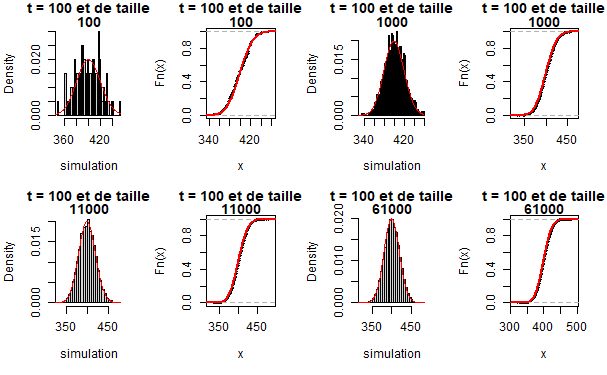

```r
# test de la fonction avec HPP_sim_3

par(mfrow = c(2,4))
l = 4
t = 100
n = 10000
simulation = NULL

for(n in c(100,900,10000,50000)){

  for(i in c(1:n)){
  simulation = c(simulation,(length(HPP_sim_3(t,l))))
}
title = c("t = 100 et de taille",toString(length(simulation)))
hist(simulation,probability =T,nclass=50,main = title)
lines(c(1:max(simulation)),dpois(c(1:max(simulation)),l*t),col="red")

title =
plot(ecdf(simulation),main=title)
lines(c(300:500),ppois(c(300:500),t*l),col="red",lwd=2)
}
```

# R2 : Statistical Analysis

Ici on calcul un intervalle de confiance pour notre estimateur du maximum de vraissemblance. Pour son calcul on aura besoin de simuler un HPP et de connaitre les Tk.

```r
# inputs :
# Tk : les temps de saut pour un HPP
# l : paramètre de la loi exponentielle

graph_IC <- function(Tk,l,t){

  lambda_est = NULL
  U_est = NULL
  L_est = NULL



  # on ne commence par à zero car ici ce sont des propriétés asymptotiques

  for (i in c(1:length(Tk))){
    lambda_est = c(lambda_est,(i-1)/Tk[i+1])
    U_est = c(U_est,lambda_est[i]/(1-qnorm(0.975)/sqrt(i)))
    L_est = c(L_est,lambda_est[i]/(1+qnorm(0.975)/sqrt(i)))
  }
  n = length(lambda_est)
  df_plot = data.frame(lambda_est = lambda_est[as.numeric(n/10):n],
                  U_est = U_est[as.numeric(n/10):n],
                  L_est = L_est[as.numeric(n/10):n],
                  x = c(as.numeric(n/10):n))

  p = ggplot(data = df_plot , aes(x))+
    geom_line(aes(y = lambda_est), colour="blue") +
    geom_ribbon(aes(ymin=L_est, ymax=U_est), alpha=0.2)+
    geom_hline(yintercept = l)+
    ggtitle(paste("IC sur l'estimateur de lambda = ",l,"et t = ",t))+
    xlab("nombre de sauts")+
    ylab("estimation de lambda")
  plot(p)
}
```

Test :

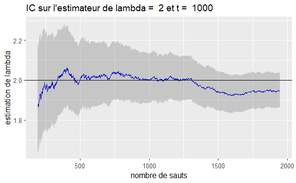

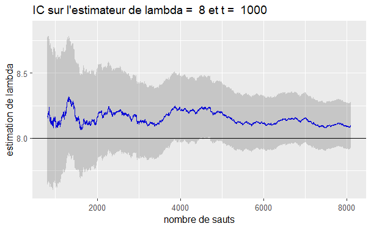

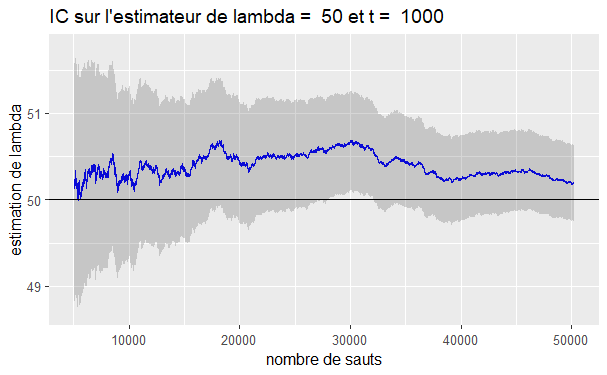

```r
t = 1000
for(l in c(2,8,50)){
  Tk = HPP_sim_3(t,l)
  graph_IC(Tk,l,t)
}
```

# R3 : Simulation of sample paths of M/M/K queueing systems

## Fonction qui nous simule une trajectoire du processus

```r
SamplePaths <- function(Y_0,K,lambda,mu,t){
  # Input :
  # Y_0 : nombre de clients à l'instant t=0
  # K : nombre de serveurs
  # lambda : paramètres de la loi exponentielle du temps d'arrivée des clients
  # mu : paramètre de la loi exponentielle du temps de service des clients
  # t : longueur de la simulation

  # Output : les temps de saut ainsi que les états occupés

  path = c(Y_0)
  time = c(0)
  #On se donne Q, le générateur
  Q = matrix(c(-lambda,(1:K)*mu,rep(lambda,K+1)),ncol=2,byrow = FALSE)
  #les paramètres des loi exponentielles
  q = c((lambda + (0:K)*mu))
  #La matrice du processus discret {Y_n}
  P = abs(Q/q)
  #rajouter les 0 : P(i,i)
  P = matrix(c(P[,1],rep(0,K+1),P[,2]),ncol = 3,byrow = FALSE)
  #La loi sachant Y_0 = 0
  P[1,] = c(0,0,1)

  temps = 0
  duree_sej = 0
  i = Y_0
  while(temps < t){
    if(i < K){
      #Tirage de la durée de séjour
      duree_sej = rexp(1,q[i+1]) # i+1 car les indices commencent à 1 en R
      #Tirage dans (i-1,i,i+1) avec proba de tirage Y=i égale à 0.
      i = sample(c(i-1,i,i+1),1,prob = P[i+1,])
    }
    else{
      #Tirage de la durée de séjour
      duree_sej = rexp(1,q[K+1])
      #Tirage dans (i-1,i,i+1) avec proba de tirage Y=i égale à 0.
      i = sample(c(i-1,i,i+1),1,prob = P[K+1,])

    }
    path = c(path,i)
    time = c(time,duree_sej)
    temps = temps + duree_sej

  }

  time = cumsum(time)

  #au dernier temps, on dépasse t donc en dernier état on met l'état occupé et t_fin = t
  path[length(path)] = path[length(path)-1]
  time[length(time)] = t

  return(list(time = time,path = path))

}
```

## Fonction qui trace la trajectoire à partir de la simulation

```r
plotPath <- function(time,path){
  df = data.frame(Temps = time,
                  Chemin = path)

  ggplot()+
    geom_step(data = df , aes(x = Temps , y = Chemin))+
    geom_point(data=df, mapping=aes(x=Temps, y=Chemin), color="red")
}
```

## 1ères simulations

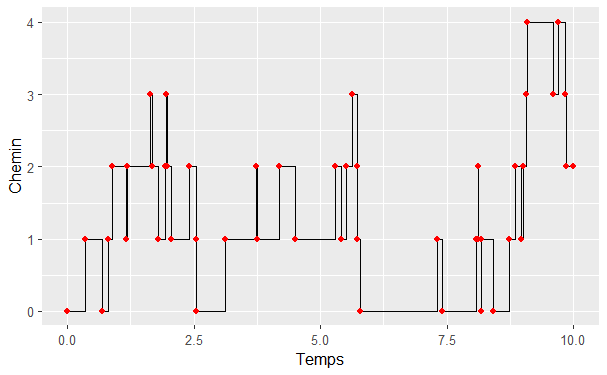

```r
res1 = SamplePaths(Y_0 = 0,K = 3,lambda = 2,mu = 2,t = 10)
plotPath(res1$time,res1$path)
```

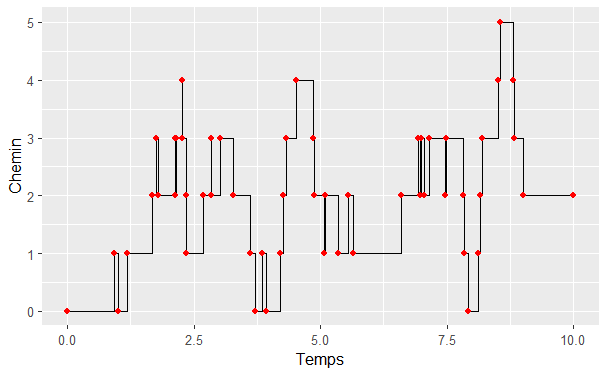

```r
res2 = SamplePaths(Y_0 = 0,K = 7,lambda = 2,mu = 2,t = 10)
plotPath(res2$time,res2$path)
```

## Cas Lambda/(K*mu) >= 1

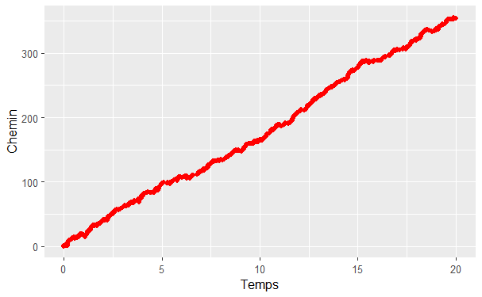

```r
res1 = SamplePaths(Y_0 = 0,K = 3,lambda = 25,mu = 3,t = 20)
plotPath(res1$time,res1$path)
```

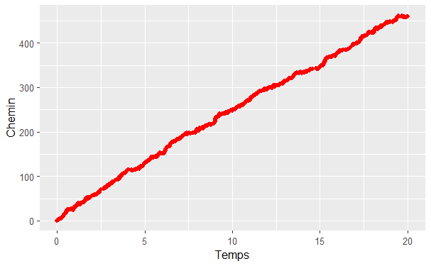

```r
res2 = SamplePaths(Y_0 = 0,K = 3,lambda = 30,mu = 3,t = 20)
plotPath(res2$time,res2$path)
```

## Cas Lambda/(K*mu) < 1

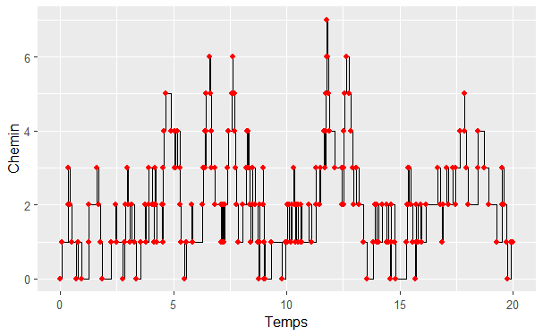

```r
res1 = SamplePaths(Y_0 = 0,K = 3,lambda = 5,mu = 3,t = 20)
plotPath(res1$time,res1$path)
```

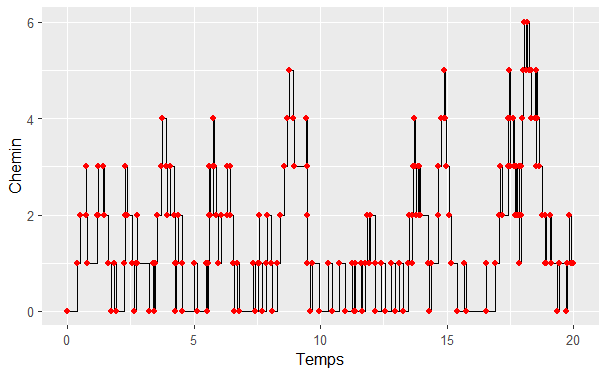

```r
res2 = SamplePaths(Y_0 = 0,K = 10,lambda = 5,mu = 3,t = 20)
plotPath(res2$time,res2$path)
```

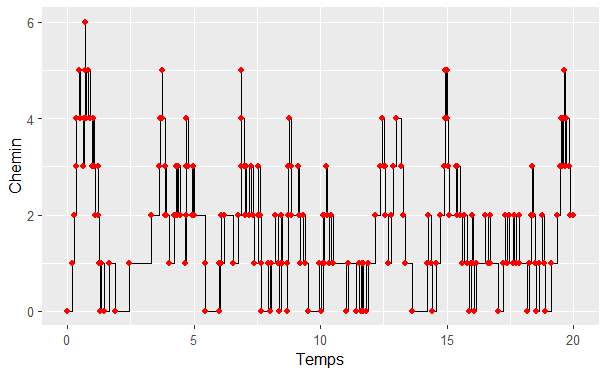

```r
res2 = SamplePaths(Y_0 = 0,K = 20,lambda = 5,mu = 3,t = 20)
plotPath(res2$time,res2$path)
```

## Fonction pour réaliser un n-échantillon de la loi de X_t

```r
echantillon_loi_Xt = function(t,Y_0,n,K,lambda,mu){

  real = c()
  Data = replicate(n,SamplePaths(Y_0,K,lambda,mu,t)$path)
  for (i in Data){
    #On récupère l'état occupé à la date finale t
    real = c(real,i[length(i)])
  }
  return(real)
}
```

## Fonction qui calcule la probabilité invariante

```r
ProbaInv <- function(lambda,mu,K,nb_max_etats){
  # nb_max_etats : nombre d'états sur lesquels on va comparer la probabilité invariante à nos approximations

  if(lambda >= K*mu){
    return('Pas de probabilité invariante sous cette condition')
  }

  i_max = nb_max_etats - 1
  rho = lambda/(K*mu)
  ratio = lambda/mu
  S = sum(ratio^(0:(K-1))/factorial(0:(K-1))) + (ratio^K)/(factorial(K)*(1-rho))

  if(i_max <= K){
    return((1/S)*(ratio^(0:i_max))/factorial((0:i_max)))
  }
  else{
    return(c((1/S)*(ratio^(0:K))/factorial((0:K)),(1/S)*(ratio^K/factorial(K))*rho^(1:(i_max-K))))
  }
}
```

## Comparaison sur un unique barplot des deux approximations et de la probabilité invariante

```r
comparaison_pi <- function(t,Y_0,n,K,lambda,mu){
  if(lambda >= K*mu){
    return('Pas de convergence sous cette condition')
  }

  t1 <- Sys.time()
  #Tirage des X_t pour t grand
  assymptotic_distrib = echantillon_loi_Xt(t,Y_0,n,K,lambda,mu)
  t2 <- Sys.time()
  print(paste('Temps Convergence Loi',t2 - t1))


  #Convergence en Loi de Pi_t vers Pi
  frequency_assymptotic_distrib = as.numeric(table(assymptotic_distrib)/length(assymptotic_distrib))

  #nb d'états différents sur lesquels il suffit de comparer
  nb_etats_loi_assymp = length(frequency_assymptotic_distrib)

  t1 <- Sys.time()
  #Approximation de pi par la loi forte des grands nombres pour CTMC
  real = SamplePaths(Y_0,K,lambda,mu,t)

  nb_etats_real = length(as.numeric(table(real$path)))
  LFGN = c()
  for(i in 0:(nb_etats_real-1)){

    ind = which(real$path == i)
    #si il y a l'indice où T = t, pas d'indice "plus loin" donc on supprime sans perte d'info
    if(length(real$path) %in% ind){
      ind = ind[-length(ind)]
    }

    freq_duree_sej_i = sum(real$time[ind+1]-real$time[ind])/t
    LFGN = c(LFGN,freq_duree_sej_i)
  }
  t2 <- Sys.time()
  print(paste('Temps Convergence LFGN',t2 - t1))

  nb_etats = min(c(nb_etats_loi_assymp,nb_etats_real))

  LFGN = LFGN[1:nb_etats]
   frequency_assymptotic_distrib = frequency_assymptotic_distrib[1:nb_etats]

  #Loi exacte de Pi
  proba_inv = ProbaInv(lambda,mu,K,nb_etats)

  print(paste("Nombre d'états où l'on compare les lois",nb_etats))

  print(paste('Conv LFGN',sum(abs(proba_inv-LFGN))))

  print(paste('Conv Loi',sum(abs(proba_inv-frequency_assymptotic_distrib))))

  df = data.frame(Loi = c(rep("Loi assymptotique",length(frequency_assymptotic_distrib)),rep("Probabilité invariante",length(proba_inv)),rep("LFGN",length(LFGN))), Etats = c(seq(from = 0, to = (length(proba_inv)-1)),seq(from = 0, to = (length(proba_inv)-1)),seq(from = 0, to = (length(proba_inv)-1))),Densite = c(frequency_assymptotic_distrib,proba_inv,LFGN))

  title <- paste("Étude de la convergence du processus M/M/K")
  p <- ggplot(data=df, aes(x=Etats, y=Densite, fill=Loi)) +
  geom_bar(stat="identity", color="black", position=position_dodge())+
  theme_minimal()  + ggtitle(title) + theme(plot.title = element_text(hjust = 0.5))
  p + scale_fill_manual(values=c('#999999','#E69F00','#0066FF'))
}
```

#### Test

**Cette partie peut prendre du temps à s’executer**.

```
[1] "Temps Convergence Loi 0.53606390953064"
[1] "Temps Convergence LFGN 0.0019991397857666"
[1] "Nombre d'états où l'on compare les lois 5"
[1] "Conv LFGN 0.266846114237419"
[1] "Conv Loi 0.0649999999999999"
```

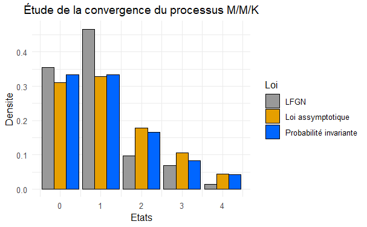

```r
n=500
# n = 200 # à décommenter si n = 500 prend trop de temps/ressources
comparaison_pi(10,0,n,2,5,5)
```

```
[1] "Temps Convergence Loi 3.13600087165833"
[1] "Temps Convergence LFGN 0.00600004196166992"
[1] "Nombre d'états où l'on compare les lois 10"
[1] "Conv LFGN 0.090714103495883"
[1] "Conv Loi 0.06496875"
```

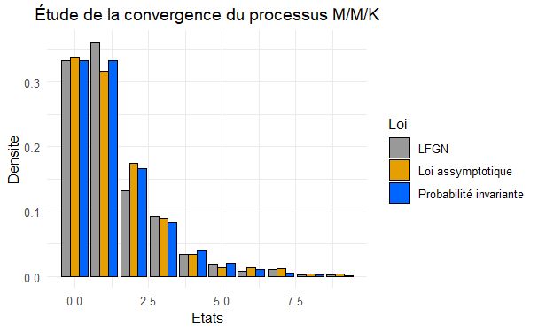

```r
comparaison_pi(50,0,n,2,5,5)
```

```
[1] "Temps Convergence Loi 59.4889998435974"
[1] "Temps Convergence LFGN 0.269996881484985"
[1] "Nombre d'états où l'on compare les lois 9"
[1] "Conv LFGN 0.0367976414736773"
[1] "Conv Loi 0.0973125"
```

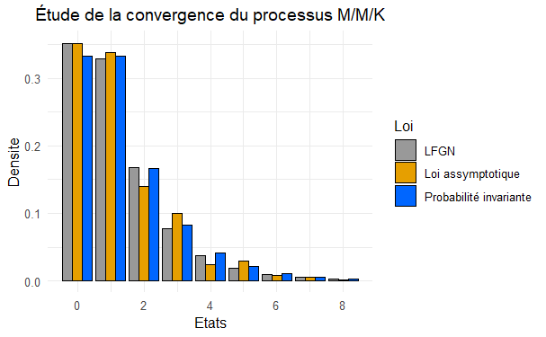

```r
comparaison_pi(500,0,n,2,5,5)
```

```
[1] "Temps Convergence Loi 0.56404185295105"
[1] "Temps Convergence LFGN 0.00101613998413086"
[1] "Nombre d'états où l'on compare les lois 4"
[1] "Conv LFGN 0.051861298956123"
[1] "Conv Loi 0.0537349357933236"
```

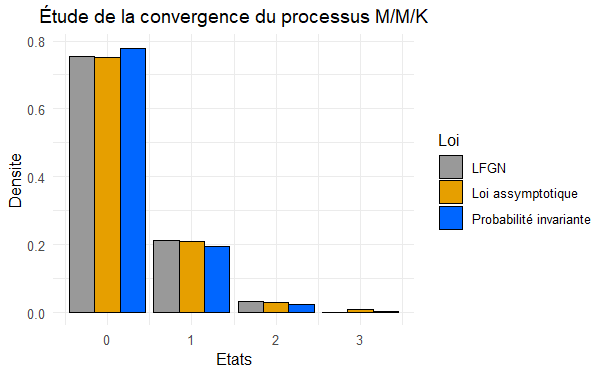

```r
n=500
# n = 200 # à décommenter si n = 500 prend trop de temps/ressources
comparaison_pi(10,0,n,10,5,20)
```

```r
comparaison_pi(50,0,n,10,5,20)
```

[output not shown]

[output not shown]

```r
comparaison_pi(500,0,n,10,5,20)
```

[output not shown]

#R4 : A basic implementation in the finite state space case

## Loi de X_t tronquée avec une précision fixée

```r
pi_t <-function(epsilon,lambda_chap,t,alpha,P){
  # Input
  # epsilon : précision souhaitée
  # lambda_chap : paramètre d'uniformisation
  # t : temps d'étude
  # alpha : loi initiale
  # P : matrice du processus uniformisé

  # Output : valeur tronquée de Pi_t

  #n à partir de la précision epsilon
  n = qpois(p = 1-epsilon,lambda_chap*t)
  #Vecteur de la loi de X_t
  res = matrix(rep(0,nrow(P)),nrow  = 1)
  # Matrice des puissances, identité pour n = 0
  P_p = diag(rep(1,nrow(P)))
  for(i in 0:n){
    res <- res + exp(-lambda_chap*t)*(lambda_chap*t)^(i)*(alpha%*%P_p)/factorial(i)
    #matrice des puissances
    P_p = P_p%*%P
  }
  return(res)
}
```

### Exemple tirée de la diapo 77 Cours

```r
Q = matrix(c(-2,1,1,1,-1,0,2,1,-3),nrow = 3,byrow = TRUE)
#Son unique probabilité invariante
pi = c(0.375,0.5,0.125)
#Données pour la troncature
lambda_chap = 4
#Matrice du processus discret
P_chap = diag(rep(1,nrow(Q))) + (1/lambda_chap)* Q
#Loi initiale, peut importe laquelle si convergence (on évite la probabilité invariante)
alpha = matrix(c(1/2,1/4,1/4),nrow = 1)
```

#### On va tester pour plusieurs t

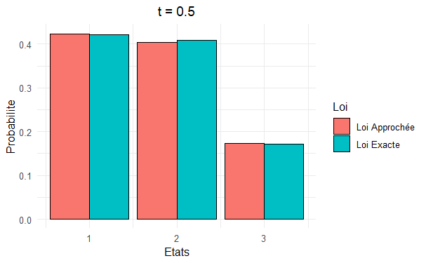

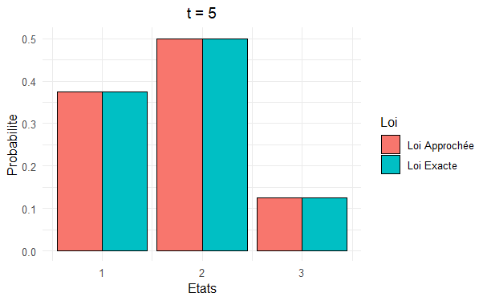

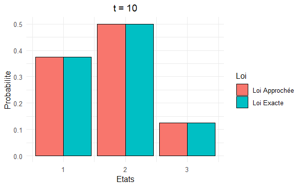

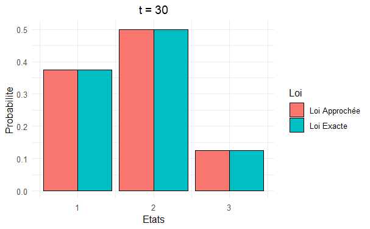

```r
epsilon = 1e-1
for(t in c(0.5,5,10,30)){
  loi_X_t = pi_t(epsilon,lambda_chap,t,alpha,P_chap)/sum(pi_t(epsilon,lambda_chap,t,alpha,P_chap))
  P_t_exacte = alpha%*%expm(Q*t)


  df = data.frame(Loi = c(rep("Loi Approchée",length(loi_X_t)),rep("Loi Exacte",length(loi_X_t))), Etats = c(seq(from = 1, to = length(loi_X_t)),seq(from = 1, to = length(loi_X_t))),Probabilite = c(loi_X_t,P_t_exacte))

  title <- paste("t =",t)
  p <- ggplot(data=df, aes(x=Etats, y=Probabilite, fill=Loi)) +
  geom_bar(stat="identity", color="black", position=position_dodge())+
  theme_minimal()  + ggtitle(title) + theme(plot.title = element_text(hjust = 0.5))
  p + scale_fill_manual(values=c('#999999','#E69F00'))
  print(p)
}
```